# R Basic Graphs

首先介绍 R 绘图的基本方法，随后讲解如何定制图表的各个元素（标题、轴、标签、刻度线、辅助线、图例等），最后关注如何定制一组图和混合图。

包含了几乎所有 R 绘图所需的一般知识，但不包含对 `ggplot2` （一个专业于绘图的 R 包）绘图的介绍。

使用的 R 版本是 3.5.2

# 1 DATA SOURCE

研究病人对两种药物 A and B 的不同剂量的反应，首先生成数据：

```r
# 药物剂量
dose <- c(20, 30, 40, 50, 60)
drugA <- c(16, 20, 27, 40, 60)
drugB <- c(15, 18, 25, 31, 40)
dose_table <- data.frame(dose, drugA, drugB)
```

| dose | drugA | drugB |
| --- | --- | --- |
| 20 | 16 | 15 |
| 30 | 20 | 18 |
| 40 | 27 | 25 |
| 50 | 40 | 31 |
| 60 | 60 | 40 |

# 2 BASIC: DRAW AND SAVE

## 2.1 Draw a Graph

绘制散点图并连线：

- 使用 `plot()` 方法
- 第一个参数是 x，第二个参数是 y。参数 `type="b"` 意思是同时绘制点和线。

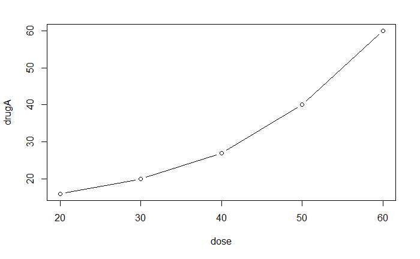

```r
plot(dose, drugA, type="b")
```

Use command `help(plot)` to learn more about `plot()`。

## 2.2 Save a Graph

可以将图表保存为 PNG, JPEG, PDF, PSF 等格式。

```r
png(filename = "my_plot.png")
jpeg(filename = "my_plot.jpg")
pdf(file="my_plot.pdf")
postscript(file = "my_plot.ps")
```

# 3 CONFIGURATION

## 3.1 Method 1: `par()`

使用 `par()` 查看和配置图表参数。

- 用参数 `no.readonly = TRUE` 查看可编辑的图标参数
- 用变量 `opar`: Original params 来备份初始配置

```r
opar <- par(no.readonly = TRUE)
opar[1:2]
```

```
$xlog
[1] FALSE

$ylog
[1] FALSE
```

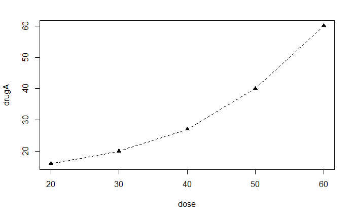

```r
# lty: change line type to dashed (=2), pch: change symbol to solid triangle (=17)
par(lty=2, pch=17)
plot(dose, drugA, type="b")
# 恢复初始配置
par(opar)
```

## 3.2 Method 2: Send in Params Directly

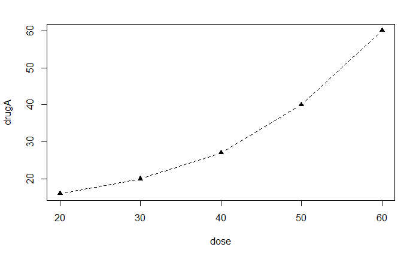

```r
plot(dose, drugA, type = "b", lty=2, pch=17)
```

## 3.3 Lines and Symbols

## 3.4 Colors

### 3.4.1 Color Params in Graph

- `col` 用于线图或饼图，可以传入向量，R 将循环使用其中的颜色
- `col.axis` 轴文本
- `col.lab` 轴标签
- `col.main` 主标题
- `col.sub` 副标题
- `fg` 前景色
- `bg` 背景色

支持各种颜色格式：`col=1`, `col="white"`, `col="#FFFFFF"`, `col=rgb(1,1,1)` or `col=hsv(0,0,1)` is OK.

### 3.4.2 Colors in R

- `colors()` 返回所有可用颜色名
- `rainbow()`, `heat.colors()`, `terrain.colors`, `topo.colors()` and `cm.colors()` 可以生成系列色
- `RColorBrewer` 包可以生成颜色

#### 3.4.2.1 Example 1: `raindow()`

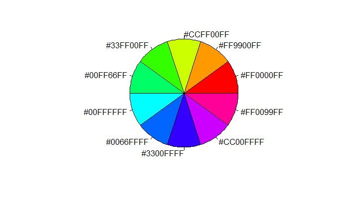

```r
n <- 10
mycolors <- rainbow(10)
pie(rep(1, n), labels = mycolors, col = mycolors)
```

#### 3.4.2.2 Example 2: `gray()`

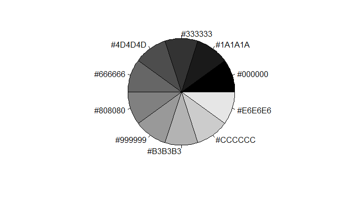

```r
n <- 10
mygrays <- gray(0:n/n)
pie(rep(1, n), labels = mygrays, col = mygrays)
```

#### 3.4.2.3 Example 3: RColorBrewer

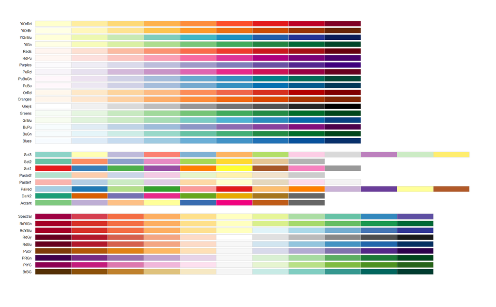

```r
library(RColorBrewer)
display.brewer.all()
```

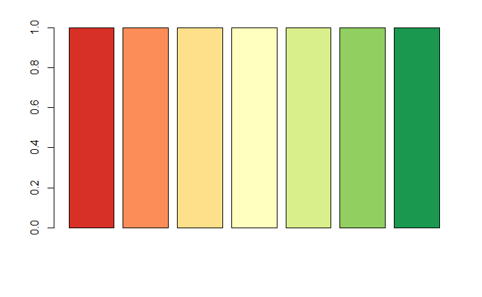

```r
n <- 7
mycolors <- brewer.pal(n, "RdYlGn")
barplot(rep(1,n), col=mycolors)
```

## 3.5 Text

图表中的文字样式也可以进行类似配置。

### 3.5.1 Font Size

在 `par()` 中传入以下参数和值，或直接传入绘图方法中。

- `cex` 基础文字大小倍数
- `cex.axis` 轴文字字号倍数，相对 `cex`，下同
- `cex.lab` 轴标签字号倍数
- `cex.main` 主标题字号倍数
- `cex.sub` 副标题字号倍数

### 3.5.2 Font Style

- `font` 基础文字粗细，=1 正常，=2 加粗，=3 意大利斜体，=4 粗斜体，=5点阵字体 (Adobe)
- `font.axis` 轴文字
- `font.lab` 轴标签
- `font.main` 主标题
- `font.sub` 副标题
- `ps` Font point size

### 3.5.3 Font Family

- `family` 字体

Windows 中字体名和具体名称之间有一个 map 的对应关系。

使用已知对应字体，可以直接将 `family` 值设置为字体名:

```r
par(family="serif")
```

使用新字体，需要用 `windowsFont()` 方法构建 map 关系：

```r
windowsFonts(
  A=windowsFont("Arial Black"),
  B=windowsFont("Bookman Old Style"),
  C=windowsFont("Comic Sans MS")
)
# 将图表字体设置为 Arial Black
par(family = "A")
```

可以使用 `names()` 方法查看可用字体。

```r
# PDF 字体
names(pdfFonts())
# 生成 pdf
pdf(file="myplot.pdf", family = "fontname")
# PostScript Format 字体
names(postscriptFonts())
# 生成 PSF
postscript(file = "myplot.ps", family = "fontname")
```

## 3.6 Height, Width and Margin

- `pin` 传入向量，分别为宽和高
- `mai` margin，图表的外边距，单位是 inches，顺序是 `c(bottom, left, top, right)`
- `mar` margin，图表的外边距，单位是行，顺序同上

```r
# 4 inch 宽，3 inch 高，上下边距为 1 inch，0.2 inch 右边距，0.5 inch 左边距
par(pin = c(4,3), mai = c(1, .5, 1, .2))
```

## 3.7 Mixed Example

配置：

1. 宽 =2 和高 =3
2. 线粗2倍，点变大1.5倍
3. 轴文字 0.75 倍，斜体
4. 点线样式在绘图函数中直接配置

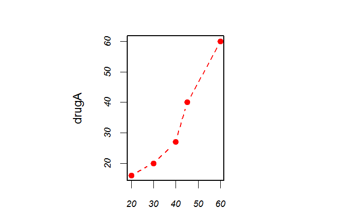

```r
dose <- c(20, 30, 40, 45, 60)
drugA <- c(16, 20, 27, 40, 60)
drugB <- c(15, 18, 25, 31, 40)
opar <- par(no.readonly=TRUE)
# 1
par(pin=c(2,3))
# 2
par(lwd=2, cex=1.5)
# 3
par(cex.axis=.75, font.axis=3)
# 4-1
plot(dose, drugA, type="b", pch=19, lty=2, col="red")
```

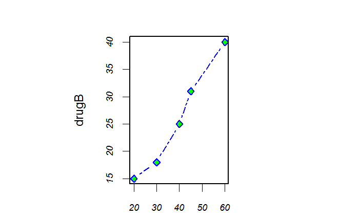

```r
# 4-2
plot(dose, drugB, type="b", pch=23, lty=6, col="blue", bg="green")
par(opar)
```

## 3.8 More Detailed Configurations

往 `plot()` 中传入更多参数，可以更好地定制图表。

绘制药物 A 的剂量与病人反应关系的图像：

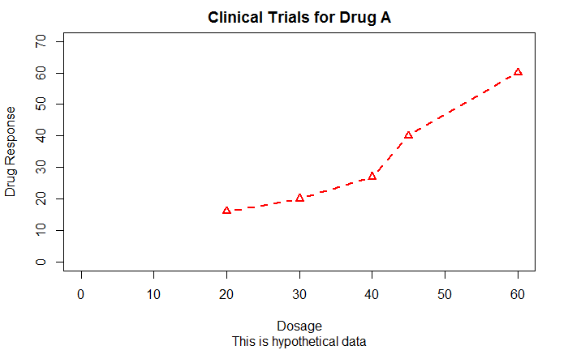

```r
plot(dose, drugA, type="b",
     col="red", lty=2, pch=2, lwd=2,
     main="Clinical Trials for Drug A",
     sub="This is hypothetical data",
     xlab="Dosage",
     ylab="Drug Response",
     xlim=c(0,60), ylim=c(0,70))
```

并不是所有绘图函数都支持这些参数，需要参考 `help()`。

### 3.8.1 Title

使用 `title()` 定制标题，基本语法是：

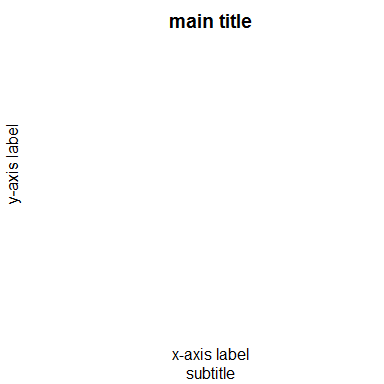

```r
plot.new()
title(main="main title", sub="subtitle",
      xlab="x-axis label", ylab="y-axis label")
```

它也可被传入图表的配置参数.

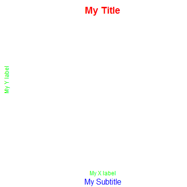

```r
plot.new()
title(main="My Title", col.main="red",
sub="My Subtitle", col.sub="blue",
xlab="My X label", ylab="My Y label",
col.lab="green", cex.lab=0.75)
```

### 3.8.2 Axes

使用 `axis()` 方法定制坐标轴，基本语法是：

```r
axis(side, at=, labels=, pos=, lty=, col=, las=, tck=, ...)
```

- `side` 指定配置的目标轴（根据轴在图表的哪一侧），1 底部，2 左侧，3 顶部，4 右侧
- `at` 在哪里画刻度线，传入数字型向量
- `labels` 刻度线处的标记文字，传入字符型向量。如果是 NULL，将使用刻度线处的数值（也即 at= 的值）。
- `pos` 与另一条轴的哪个值处相交
- `lty` 线样式
- `col` 线和刻度线颜色
- `las` label和轴平行(=0)或和轴垂直(=2)
- `tck` 刻度线的长度比例，为负在轴外，为正在轴内，=0 隐藏，=1 即为网格线。

繁琐但全面 cover 的示例：

- 使用了 `lines()` 方法绘制线图。
- 使用了 `mtext()` 方法添加文字。

```r
# Specifies data
x <- c(1:10)
y <- x
z <- 10/x
opar <- par(no.readonly=TRUE)
# Increases margins
par(mar=c(5, 4, 4, 8) + 0.1)
# Plots x vs. y, suppressing annotations
plot(x, y, type="b",
     pch=21, col="red",
     yaxt="n", lty=3, ann=FALSE)
# Adds an x versus 1/x line
lines(x, z, type="b", pch=22, col="blue", lty=2)
```

```r
# Draws the axes
axis(2, at=x, labels=x,
     col.axis="red", las=2)
axis(4, at=z, labels=round(z, digits=2),
     col.axis="blue", las=2, cex.axis=0.7, tck=-.01)
```

```r
# Adds titles and text
mtext("y=1/x", side=4, line=3, cex.lab=1, las=2, col="blue")
title("An Example of Creative Axes",
      xlab="X values",
      ylab="Y=X")
```

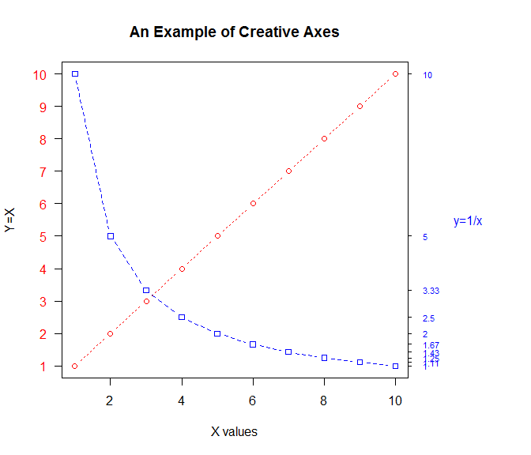

```r
par(opar)
```

添加无标签的“小刻度”需要 `Hmisc` 包的 `minor.tick()` 方法，例子见下一小节的示例图。

### 3.8.3 Reference Lines

使用 `abline(h=yvalues, v=xvalues)` 添加辅助线.

例如如下代码：

1. 在 y=1,5,7 处绘制辅助线
2. 在 x=1,3,5,7,9 处绘制辅助线

```r
# 1
abline(h=c(1,5,7))
# 2
abline(v=seq(1, 10, 2), lty=2, col="blue")
```

### 3.8.4 Legend

使用 `legend()` 方法配置图例和其样式。

```r
legend(location, title, legend, ...)
```

- `location` 图例位置，语法可以是以下任意一种
  - `x,y` 上左侧为原点的距离坐标系
  - `locator(1)` 鼠标位置
  - `bottom, bottomleft, left, topleft, top, topright, right, bottomright, center` 在图内的某个方位
    - `inset=` 参数在方位基础上位移一段距离
- `title` 图例标题，字符串 (optional)
- `legend` 图例标签，字符串向量
- `...` 其他图表参数，比如`col=`颜色，`pch=`点样式，`lwd=`,`lty=`线样式，`fill=`图例盒子的颜色，都传入向量
- `horiz=TRUE` 将图例设置成水平排列而不是垂直排列
- `bty` 图例盒子类型，`bg`背景色，`cex`字号，`text.color`文字颜色

See `help(legend)` for more details.

### 3.8.5 Legend Example

对比药物 A 和药物 B 的药效。

```r
dose <- c(20, 30, 40, 45, 60)
drugA <- c(16, 20, 27, 40, 60)
drugB <- c(15, 18, 25, 31, 40)
opar <- par(no.readonly=TRUE)
# Increases line, text, symbol, and label font size
par(lwd=2, cex=1.5, font.lab=2)
# Generates the graph
plot(dose, drugA, type="b",
     pch=15, lty=1, col="red", ylim=c(0, 60),
     main="Drug A vs. Drug B",
     xlab="Drug Dosage", ylab="Drug Response")
lines(dose, drugB, type="b",
      pch=17, lty=2, col="blue")
```

```r
abline(h=c(30), lwd=1.5, lty=2, col="gray")
# Adds minor tick marks
library(Hmisc)
minor.tick(nx=3, ny=3, tick.ratio=0.5)
```

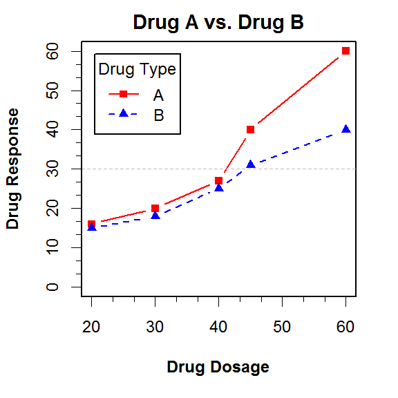

```r
legend("topleft", inset=.05, title="Drug Type", c("A","B"),
       lty=c(1, 2), pch=c(15, 17), col=c("red", "blue"))
par(opar)
```

### 3.8.6 Text Annotations

使用 `text()` 或 `mtext()` 为图表添加文字。

- `text()` 在**图中**添加文字，尤其用于标识某个特殊点
  - 语法是 `text(location, "text to place", pos, ...)`
- `mtext()` 在**外边距的空白**添加文字
  - 语法是 `mtext("text to place", side, line=n, ...)`

二者共同的参数：

- `location` 位置。值为 `x,y` 表示坐标位置，或 `locator(1)` 表示鼠标位置
- `pos` 相对于 `location` 参数值的位置. 1 = below, 2 = left, 3 = above, 4 = right.
- `side` 放置在外边距的哪一侧，1 = bottom, 2 = left, 3 = top, 4 = right。
  - `line` 参数还可以配置文字与坐标轴的距离
  - `adj=0` 左下角对齐，`adj=1`右上角对齐
- 其他参数，比如字号`cex`，颜色`col`和粗细`font`

例子：

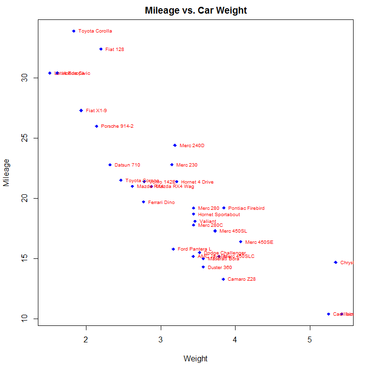

```r
attach(datasets::mtcars)
plot(wt, mpg,
     main="Mileage vs. Car Weight",
     xlab="Weight", ylab="Mileage",
     pch=18, col="blue")
text(wt, mpg,
     row.names(mtcars),
     cex=0.6, pos=4, col="red")
```

```r
detach(datasets::mtcars)
```

```r
opar <- par(no.readonly=TRUE)
par(cex=1.5)
plot(1:7,1:7,type="n")
text(3,3,"Example of default text")
```

```r
text(4,4,family="mono","Example of mono-spaced text")
text(5,5,family="serif","Example of serif text")
```

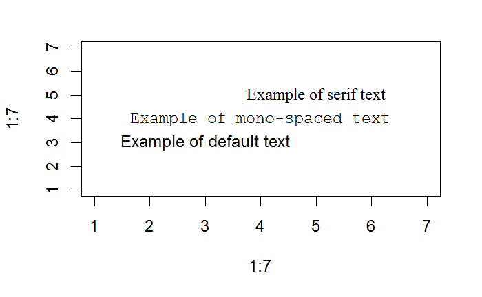

```r
par(opar)
```

### 3.8.7 Math Annotations

可以往图表中添加数学表达式，规则见 `help(plotmath)`.

使用 `plotmath()` 方法可以向图表的组件或在图中添加数学公式。

# 4 MULTIPLE GRAPHS

## 4.1 Grouped Graphs

使用 `par()` 或 `layout()` 方法可以混合图表。

- `par()` 里的参数
  - `mfrow=c(nrows, ncols)` 按行排列，生成 nrow 行 nrow 列的图表阵列
  - `mfcol=c(nrows, ncols)` 按列排列

### 4.1.1 `par()`

例子：

```r
attach(mtcars)
opar <- par(no.readonly=TRUE)
par(mfrow=c(2,2))
plot(wt,mpg, main="Scatterplot of wt vs. mpg")
plot(wt,disp, main="Scatterplot of wt vs. disp")
```

```r
hist(wt, main="Histogram of wt")
boxplot(wt, main="Boxplot of wt")
```

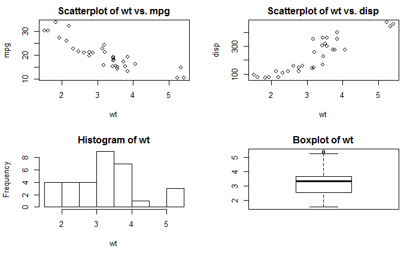

```r
par(opar)
```

```r
detach(mtcars)
```

注意上述代码中 `hist()` 方法，即使不传入 `main` 参数，图的默认标题也会是 “Histagram of xxx”.

### 4.1.2 `layout()`

`layout` 接收一个矩阵 (*matrix*)，根据**矩阵规模**和矩阵内的**数字**来排列图表。

可选参数: * `widths` 列宽，传入向量 * `heights` 行高，传入向量 * 相对长度使用数字型向量，绝对长度使用 `lcm()` 值向量

例子 1：不设置列宽和行高的基本图组

```r
attach(mtcars)
layout(
  matrix(c(1,1,2,3), 2, 2, byrow=TRUE)
  )
hist(wt)
hist(mpg)
```

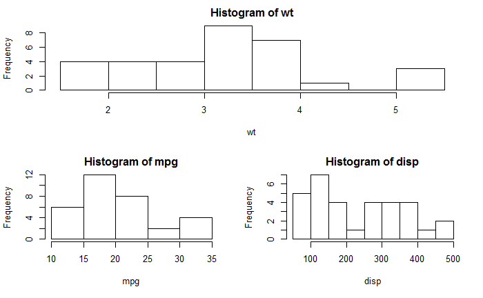

```r
hist(disp)
```

```r
detach(mtcars)
```

例子 2：设置列宽和行高的图组

```r
attach(mtcars)
layout(matrix(c(1, 1, 2, 3), 2, 2, byrow = TRUE),
       widths=c(3, 1), heights=c(1, 2))
hist(wt)
hist(mpg)
```

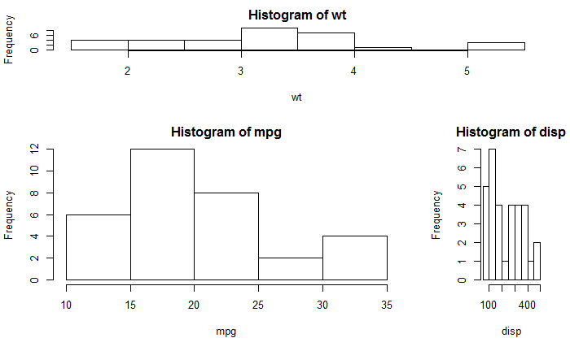

```r
hist(disp)
```

```r
detach(mtcars)
```

See `help(layout)` for more details.

## 4.2 One Single Graph Combining Graphs

使用图表配置参数 `fig` 将多个图合并到同一张图里，定制更高级的图表。

`fig` 的参数：

```
* 规定一个坐标系 `(x,y)`，左下角 `(0,0)`，右上角 `(1,1)`
* 第一个参数是向量 `c(x1, x2, y1, y2)`，意为图形的横坐标从 x1 到 x2，纵坐标从 y1 到 y2
* 参数 `new=TRUE` ，表示在旧图上应用一个新图。
```

例子：在点阵图的上方和右侧增加箱线图

```r
opar <- par(no.readonly=TRUE)
par(fig=c(0, 0.8, 0, 0.8))
plot(mtcars$wt, mtcars$mpg,
     xlab="Miles Per Gallon",
     ylab="Car Weight")
# Adds a box plot above
par(fig=c(0, 0.8, 0.55, 1), new=TRUE)
```

```r
boxplot(mtcars$wt, horizontal=TRUE, axes=FALSE)
# Adds a box plot to the right
par(fig=c(0.6, 1, 0, 0.8), new=TRUE)
```

```r
boxplot(mtcars$mpg, axes=FALSE)
mtext("Enhanced Scatterplot", side=3, outer=TRUE, line=-3)
```

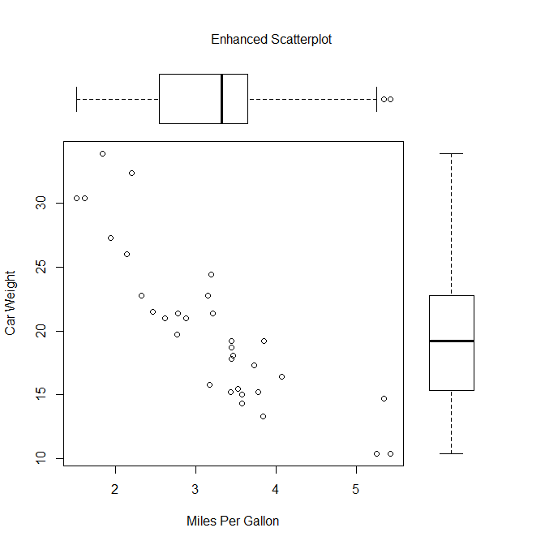

```r
par(opar)
```

**为什么箱线图和点阵图`fig`参数里，向量的横纵坐标参数加起来超过了 1 ？**

因为向量参数 `c(x1,x2,y1,y2)` 是指示一个绘图范围，所以允许重合。

报错 `Error in plot.new(): figure margins too large` 的解决办法也是调整向量参数。

示例代码的向量参数可以让箱线图更靠近点阵图，需要经过不断尝试，找到最好的配置。